# Evaluating the performance of IPF

**new tests for an old technique**

Robin Lovelace  
[RSAI-BIS](http://www.rsai-bis.org/) August 2013, Cambridge  
Wednesday 21<sup>st</sup> 11 - 13, early careers session

### Introduction

- Iterative proportional fitting is an established statistical technique [(Deming, 1940)](http://www.jstor.org/stable/10.2307/2235722)
- It estimates the values of internal cells, based on marginal totals:

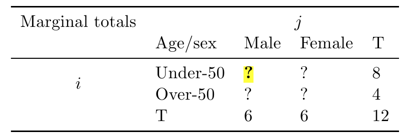

- Used in spatial microsimulation for allocating individuals to zones [(Lovelace et al., 2013)](http://dx.doi.org/10.1016/j.compenvurbsys.2013.03.004)

### How IPF works 1 - visually

Visually, this can be seen as follows:

Selection of variables used to sample individuals

People most representative of the target area selected

(Optional) process of integerisation converts weights into whole individuals

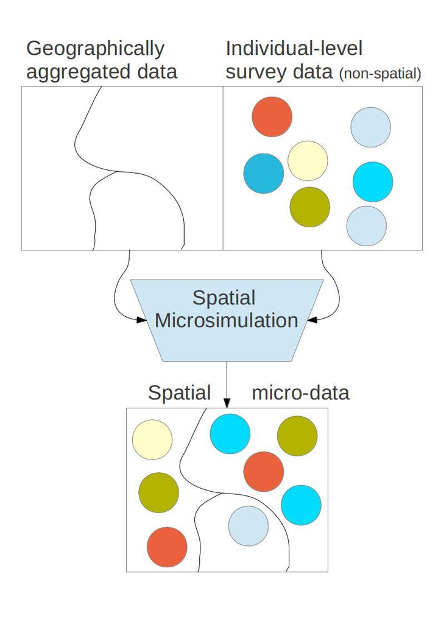

### How IPF works 2 - in maths

\[ w(n+1) = \frac{w(n) \times sT_{i}}{mT(n)_{i}} \]

- where, \( w(n+1) \) is the individual's new weight,
- \( w(n)_{ij} \) is the original weight,
- \( sT_{i} \) is the marginal total of the small area constraint
- \( mT(n)_{i} \) is the aggregate results of the weighted microdataset

Apply this algorithm, one constraint at a time, to every area in the case study

### How IPF works 3 - in code

Main algorithm:

```r
for (j in 1:nrow(all.msim)){
  for(i in 1:ncol(con1)){
 weights[which(ind.cat[,i] == 1),j,1] <- con1[j,i] /ind.agg[j,i,1]}}
```

Or in English:

- for each zone, set the new weight of individuals in each category equal to their true number divided by their current number in the simulation
- May need worked example to 'get it' (took me 3 months!)

### The need for testing

It is well-known that IPF works:

- converges towards a single result
- robust and computationally efficient
- has been used in many spatial microsimulation studies

Much less is know about the factors influencing its performance.  
Are there ways IPF should or should-not be set-up?

### Baseline scenarios

Three baseline scenarios were used:

- a simplest possible case, with 5 areas, 10 individuals and 2 constraints
- 'small area' constraints: 24 '[OA](http://www.ons.gov.uk/ons/guide-method/geography/beginner-s-guide/census/output-area--oas-/index.html)' zones, ~1,000 individuals and 3 constraints
- 'Sheffield', containing the 71 '[MSOA](http://www.ons.gov.uk/ons/guide-method/geography/beginner-s-guide/census/super-output-areas--soas-/index.html)', ~5,000 individuals and 4 constraints

Most tests were done on the 'small area' scenario

### Baseline result

- Correlation rapidly approaches 1
- Beyond 5 iterations, result is indistinguishable from 1
- perfect convergence (no empty cells)
- But are we using the right metric of model fit?

### Baseline result - visual

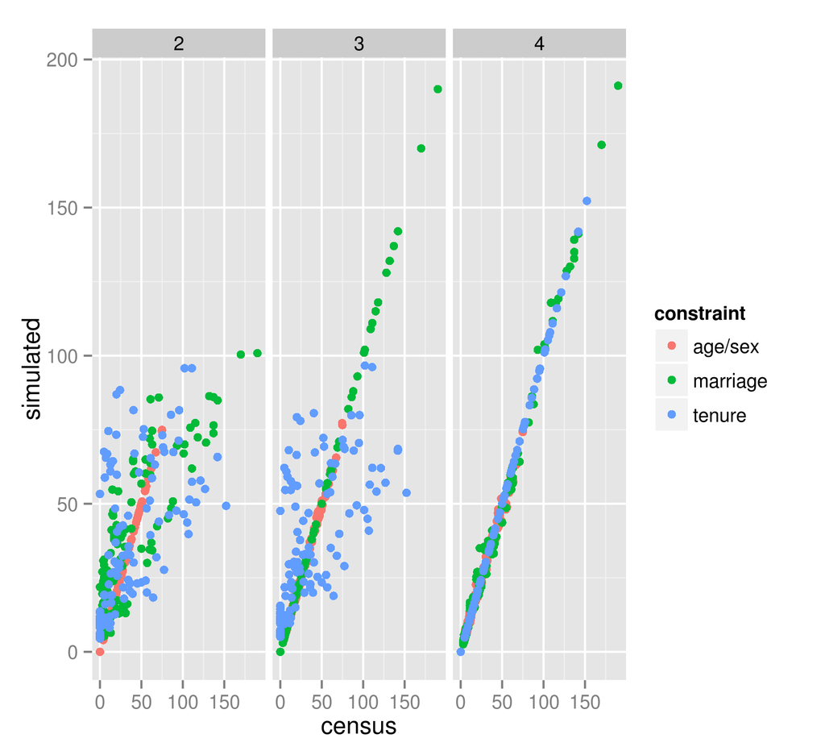

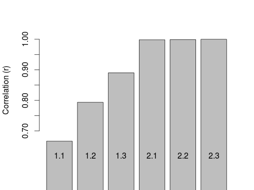

### Evaluating model fit

Commonly used options include:

- Pearson's coefficient of correlation ®
- Total and Standardised Absolute Error (TAE and SAE)
- Root mean squared (RMS)
- Z-scores
- Standard Error Around Identity (SEI)
- other metrics do exist!

### Model experiments

The impact of the following changes was tested:

- number of iterations
- number/order of constraints
- initial weights
- ratio of survey size:zone areas
- empty cells
- integerisation

### Results - Iterations and constraints

- After 4 iterations all models had near-perfect fit
- The order of constraints had some impact, but not a lot
- Fewer constraints > faster convergence (dur!)

### Results - Initial weights I

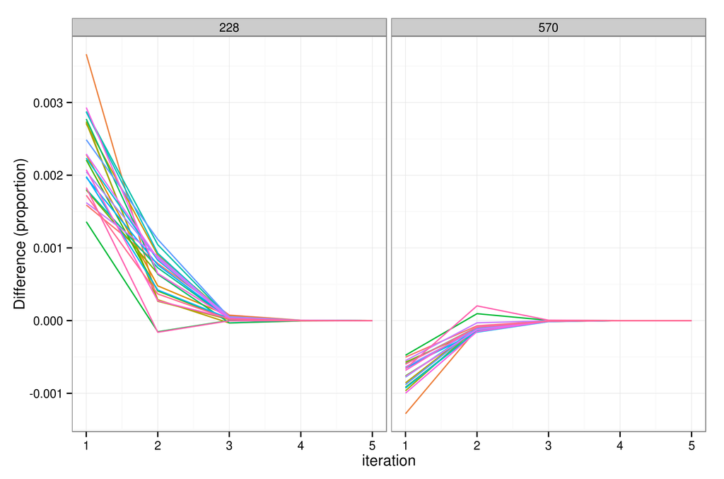

Doubling initial weight has some impact after 1 iteration, tends rapidly to 0

### Results - Initial weights II

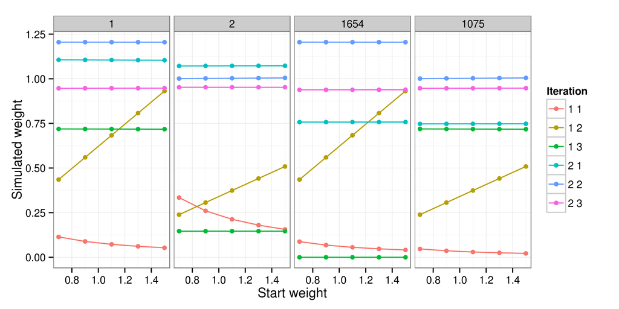

Knock-on effects on other individuals

### Conclusions and further work

- IPF is a useful procedure for various applications, but its utility can be extended and enhanced in various ways ([Pritchard and Miller, 2012](http://www.springerlink.com/index/10.1007/s11116-011-9367-4))
- Before 'trying to run', however, researchers should master walking
- Therefore these basic tests on the performance of IPF should be useful in informing future work
- Reproducible code and example data should be useful to others ('fork me' on Github !)
- More model experiments: missing cells and interactions between variables
- Is it possible for IPF to be made even faster?
- Methods for grouping individuals (e.g. into families)

### Key references (see links to others)

Deming, W. (1940). On a least squares adjustment of a sampled frequency table when the expected marginal totals are known. [The Annals of Mathematical Statistics](http://www.jstor.org/stable/10.2307/2235722)

Lovelace, R., & Ballas, D. (2013). “Truncate, replicate, sample”: A method for creating integer weights for spatial microsimulation. *CEUS*, 41, 1–11

“IPF-performance-testing” github repository - please 'clone' this and contribute! + this presentation at [www.rpubs.com/RobinLovelace](http://rpubs.com/RobinLovelace/7598)

Pritchard, D. R., & Miller, E. J. (2012). Advances in population synthesis: fitting many attributes per agent and fitting to household and person margins simultaneously. [Transportation, 39(3)](http://www.springerlink.com/index/10.1007/s11116-011-9367-4)

Thanks for listening `r.lovelace at leeds.ac.uk`